# Estratificación Rural

Técnica de estratificación

Dirección de Infraestructura Estadística y Muestreo

La base de indicadores a nivel de Unidad Primaria de Muestreo (UPM) contiene 46 variables, las cuales se encuentran codificadas en sentido positivo.

# 1 Análisis de correlación lineal

Se muestra la matriz de correlación de Pearson de la matriz de indicadores.

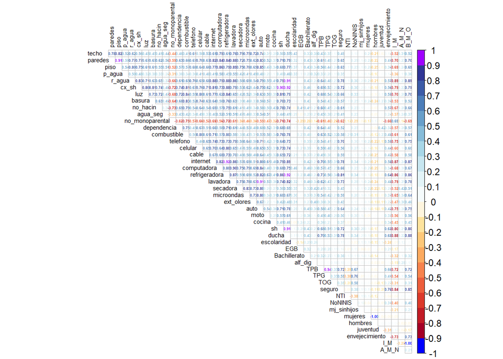

# 2 Análisis de Componentes Principales (ACP)

Para identificar el número de componentes óptimas se presenta el gráfico de sedimentación.

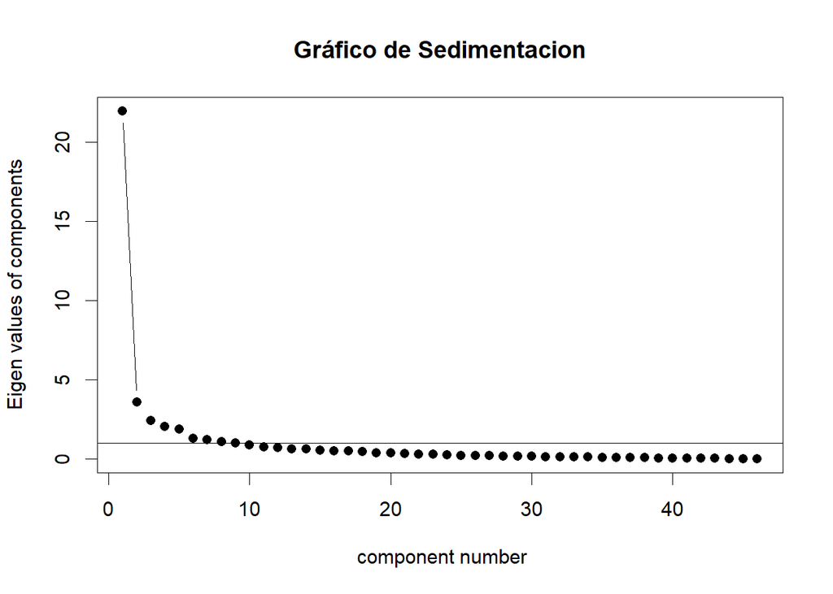

Dado que nuestro interés se centra en observar únicamente la primera componente principal, se tiene que el porcentaje de varianza que explica la misma es del 47.76 %.

Así, se presenta el gráfico de variables.

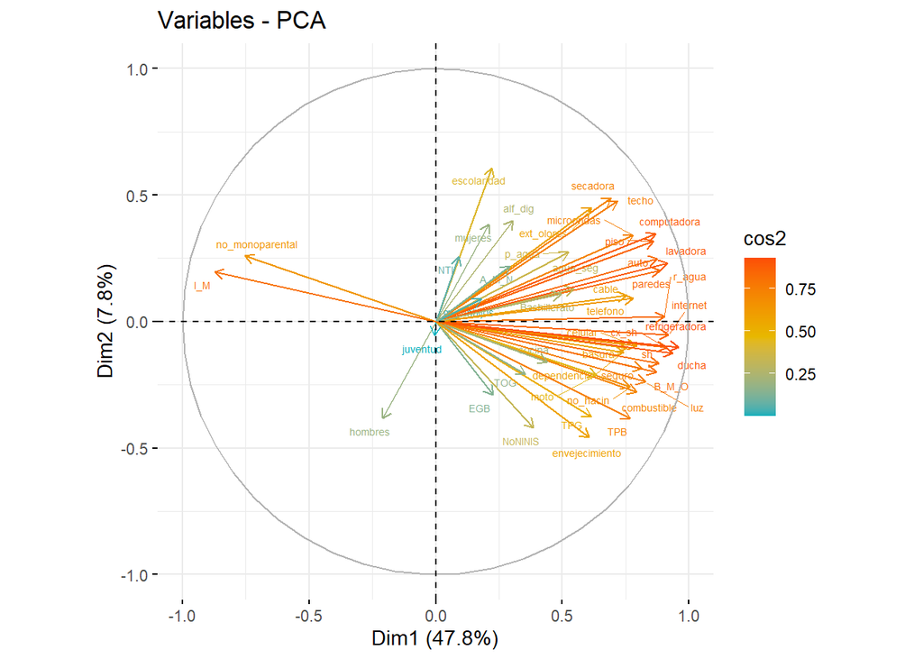

Gráfico de variables

Y finalmente se presenta la distribución del primer componente principal o medida de resumen $y$

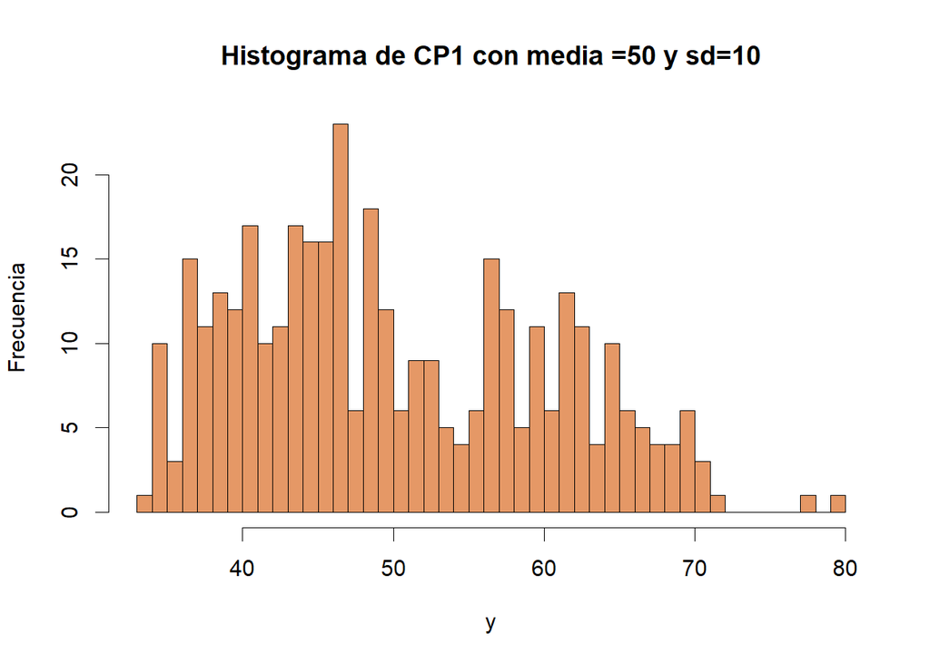

Sin embargo, es importante también analizar la calidad de representación de las variables en los componentes y la contribución de las variables a la variabilidad de cada componente para que la medida de resumen recoja la mayor cantidad de variabilidad de los datos.

Como nuestro interés se centra en la primera componente principal, el análisis se centra en dicha componente. Se empieza por analizar la calidad de representación de las variables en la primera componente, el criterio nos dice que a mayor valor del coseno cuadrado se tiene una mayor vinculación o representación de la variable en el respectivo componente.

Se decidió identificar a las variables que tienen una calidad de representación menor al $25$%, mismas que se presentan de color rojo en la tabla que se muestra a continuación:

Calidad de representación de las variables

|  | CP1 | CP2 |
| --- | --- | --- |
| refrigeradora | 0,92 | 0,01 |
| ducha | 0,88 | 0,02 |
| internet | 0,85 | 0,00 |
| lavadora | 0,84 | 0,05 |
| cx_sh | 0,83 | 0,01 |
| r_agua | 0,82 | 0,00 |
| paredes | 0,78 | 0,04 |
| sh | 0,77 | 0,03 |
| auto | 0,77 | 0,06 |
| I_M | 0,76 | 0,04 |
| B_M_O | 0,76 | 0,04 |
| computadora | 0,76 | 0,12 |
| piso | 0,74 | 0,10 |
| luz | 0,68 | 0,06 |
| seguro | 0,66 | 0,03 |
| combustible | 0,63 | 0,08 |
| celular | 0,63 | 0,01 |
| telefono | 0,61 | 0,01 |
| microondas | 0,61 | 0,12 |
| TPB | 0,59 | 0,15 |
| no_hacin | 0,59 | 0,07 |
| no_monoparental | 0,57 | 0,07 |
| cable | 0,57 | 0,01 |
| basura | 0,57 | 0,01 |
| dependencia | 0,55 | 0,01 |
| techo | 0,51 | 0,23 |
| secadora | 0,48 | 0,24 |
| moto | 0,40 | 0,05 |
| ext_olores | 0,38 | 0,20 |
| TPG | 0,38 | 0,14 |
| envejecimiento | 0,37 | 0,21 |
| agua_seg | 0,30 | 0,02 |
| p_agua | 0,28 | 0,08 |
| Bachillerato | 0,24 | 0,01 |
| cocina | 0,19 | 0,03 |
| NoNINIS | 0,15 | 0,18 |
| TOG | 0,13 | 0,04 |
| alf_dig | 0,09 | 0,16 |
| A_M_N | 0,09 | 0,05 |
| EGB | 0,05 | 0,08 |
| escolaridad | 0,05 | 0,37 |
| hombres | 0,04 | 0,15 |
| mujeres | 0,04 | 0,15 |
| mj_sinhijos | 0,03 | 0,01 |
| NTI | 0,01 | 0,07 |
| juventud | 0,00 | 0,00 |

Luego se analiza la contribución de las variables en la contabilidad de la variabilidad de la primera componente.

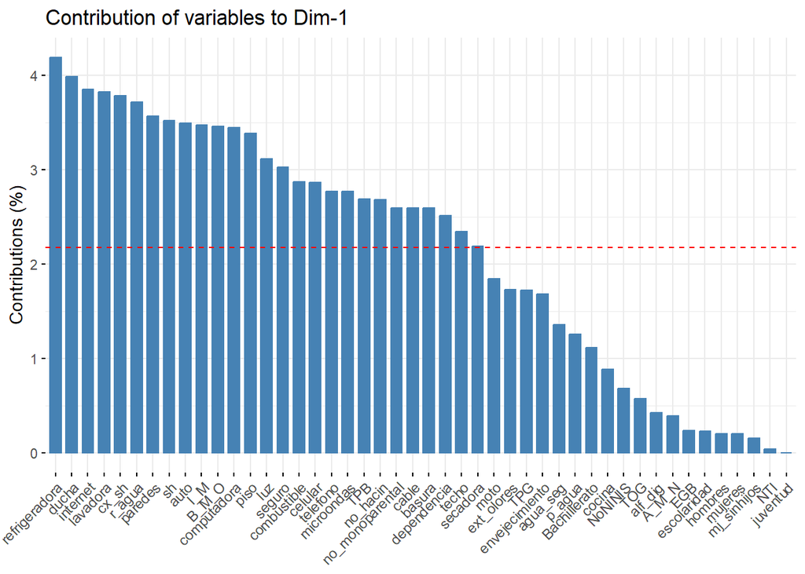

La teoría sugiere tomar aquellas variables que contribuyen menos del $\frac{1}{\text{# variables usadas en el ACP}}= \frac{1}{46}= 2.17$ %, las cuales se encuentran por debajo de la línea punteada roja.

A continuación, se presentan dos escenarios para evaluar la mejor representación de nuestra medida de resumen $y$ utilizando métodos univariados y multivariados

# 3 Escenario 1 (exclusión de las variables cuya calidad de representación es menor que el 25 %)

Las variables que se excluyen son: Bachillerato, cocina, NoNINIS, TOG, alf_dig, A_M_N, EGB, escolaridad, hombres, mujeres, mj_sinhijos, NTI, juventud

En este escenario la primera componente explica el 63.33%, dándose un aumento del 15.57 % con repecto al escenario base.

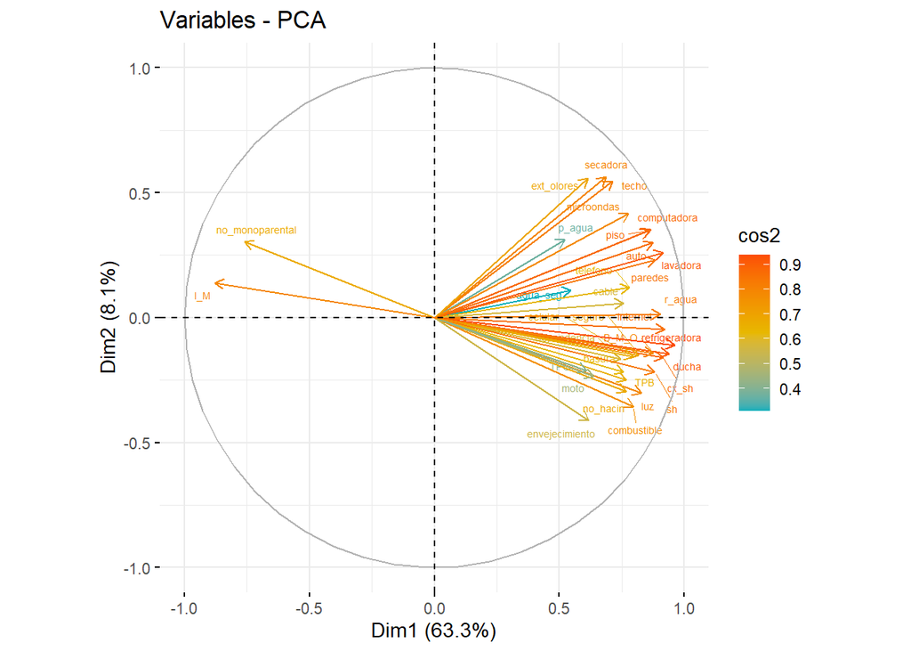

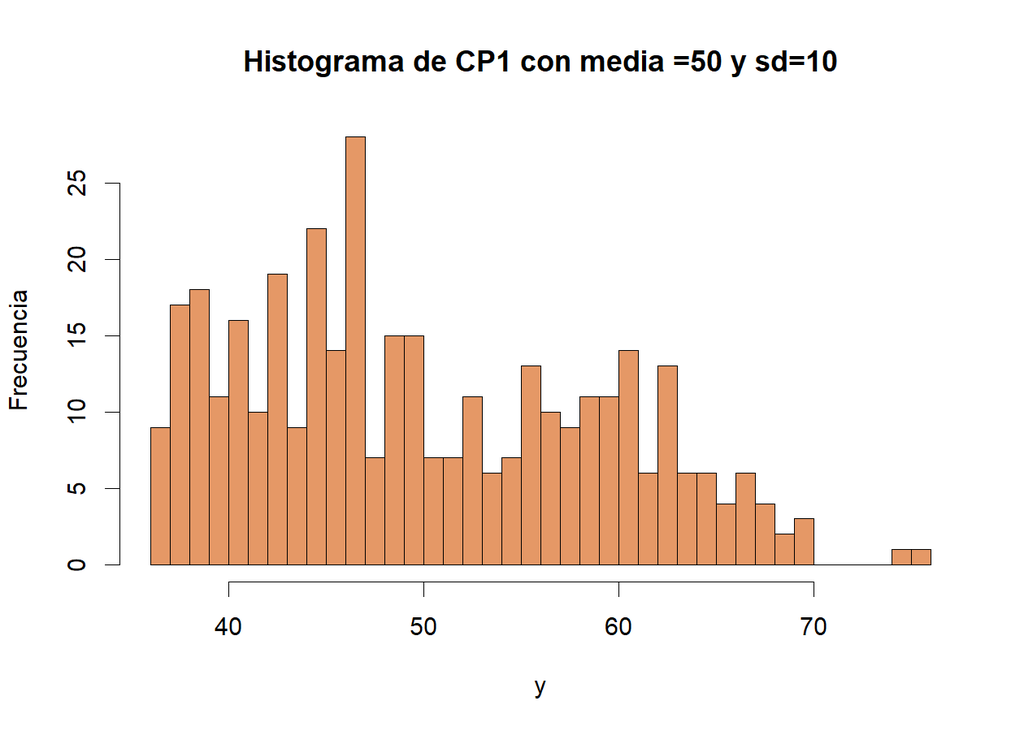

|  | Percentiles | Dalenius | LH_Sethi | LH_Kozak | Geometric | Jarque | Kmeans |
| --- | --- | --- | --- | --- | --- | --- | --- |
| techo | 0,96 | 0,96 | 0,96 | 0,96 | 0,95 | 0,97 | 0,97 |
| paredes | 0,89 | 0,89 | 0,89 | 0,89 | 0,89 | 0,90 | 0,91 |
| piso | 0,88 | 0,87 | 0,88 | 0,88 | 0,87 | 0,89 | 0,91 |
| r_agua | 0,63 | 0,63 | 0,64 | 0,63 | 0,66 | 0,68 | 0,67 |
| p_agua | 0,86 | 0,86 | 0,86 | 0,86 | 0,80 | 0,88 | 0,89 |
| cx_sh | 0,62 | 0,62 | 0,62 | 0,62 | 0,65 | 0,62 | 0,62 |
| luz | 0,85 | 0,86 | 0,84 | 0,84 | 0,86 | 0,84 | 0,84 |
| basura | 0,69 | 0,73 | 0,67 | 0,67 | 0,73 | 0,68 | 0,67 |
| no_monoparental | 0,98 | 0,98 | 0,98 | 0,98 | 0,98 | 0,98 | 0,98 |
| no_hacin | 0,92 | 0,92 | 0,92 | 0,92 | 0,92 | 0,92 | 0,92 |
| agua_seg | 0,94 | 0,94 | 0,95 | 0,95 | 0,94 | 0,95 | 0,95 |
| dependencia | 0,98 | 0,98 | 0,97 | 0,97 | 0,98 | 0,97 | 0,98 |
| escolaridad | 1,00 | 0,99 | 1,00 | 1,00 | 0,99 | 1,00 | 1,00 |
| combustible | 0,70 | 0,74 | 0,67 | 0,67 | 0,75 | 0,70 | 0,69 |
| telefono | 0,92 | 0,92 | 0,93 | 0,92 | 0,92 | 0,94 | 0,94 |
| celular | 0,75 | 0,76 | 0,73 | 0,73 | 0,77 | 0,74 | 0,75 |
| cable | 0,94 | 0,94 | 0,94 | 0,94 | 0,94 | 0,95 | 0,95 |
| internet | 0,75 | 0,75 | 0,75 | 0,76 | 0,77 | 0,77 | 0,78 |
| computadora | 0,92 | 0,91 | 0,92 | 0,92 | 0,90 | 0,93 | 0,93 |
| refrigeradora | 0,74 | 0,74 | 0,74 | 0,74 | 0,76 | 0,75 | 0,75 |
| lavadora | 0,83 | 0,82 | 0,83 | 0,83 | 0,82 | 0,85 | 0,87 |
| secadora | 0,97 | 0,97 | 0,97 | 0,97 | 0,97 | 0,98 | 0,98 |
| microondas | 0,96 | 0,96 | 0,96 | 0,96 | 0,96 | 0,97 | 0,97 |
| ext_olores | 0,99 | 0,99 | 0,99 | 0,99 | 0,98 | 0,99 | 0,99 |
| auto | 0,91 | 0,90 | 0,91 | 0,91 | 0,91 | 0,92 | 0,92 |
| moto | 0,96 | 0,96 | 0,96 | 0,96 | 0,96 | 0,96 | 0,96 |
| cocina | 0,96 | 0,96 | 0,95 | 0,95 | 0,97 | 0,96 | 0,96 |
| sh | 0,72 | 0,72 | 0,72 | 0,72 | 0,75 | 0,72 | 0,72 |
| ducha | 0,62 | 0,62 | 0,62 | 0,62 | 0,66 | 0,63 | 0,62 |
| alf_dig | 1,00 | 1,00 | 1,00 | 1,00 | 0,99 | 1,00 | 1,00 |
| EGB | 0,99 | 0,99 | 0,99 | 0,99 | 0,99 | 0,99 | 0,99 |
| Bachillerato | 0,97 | 0,98 | 0,97 | 0,97 | 0,98 | 0,97 | 0,98 |
| NTI | 1,00 | 1,00 | 1,00 | 1,00 | 1,00 | 1,00 | 1,00 |
| NoNINIS | 0,98 | 0,98 | 0,98 | 0,98 | 0,98 | 0,98 | 0,98 |
| seguro | 0,95 | 0,95 | 0,95 | 0,95 | 0,95 | 0,95 | 0,95 |
| mj_sinhijos | 1,00 | 1,00 | 1,00 | 1,00 | 1,00 | 1,00 | 1,00 |
| mujeres | 1,00 | 1,00 | 1,00 | 1,00 | 1,00 | 1,00 | 1,00 |
| hombres | 1,00 | 1,00 | 1,00 | 1,00 | 1,00 | 1,00 | 1,00 |
| juventud | 1,00 | 1,00 | 1,00 | 1,00 | 1,00 | 1,00 | 1,00 |
| envejecimiento | 0,99 | 0,99 | 0,99 | 0,99 | 0,99 | 0,99 | 0,99 |
| I_M | 0,54 | 0,56 | 0,54 | 0,54 | 0,62 | 0,62 | 0,60 |
| B_M_O | 0,54 | 0,56 | 0,55 | 0,54 | 0,62 | 0,62 | 0,60 |
| A_M_N | 1,00 | 1,00 | 1,00 | 1,00 | 1,00 | 1,00 | 1,00 |
| G(S) | 37,78 | 37,91 | 37,72 | 37,71 | 38,11 | 38,14 | 38,18 |

Se puede ver que el método de LH_Kozak tiene el menor efecto de diseño generalizado.

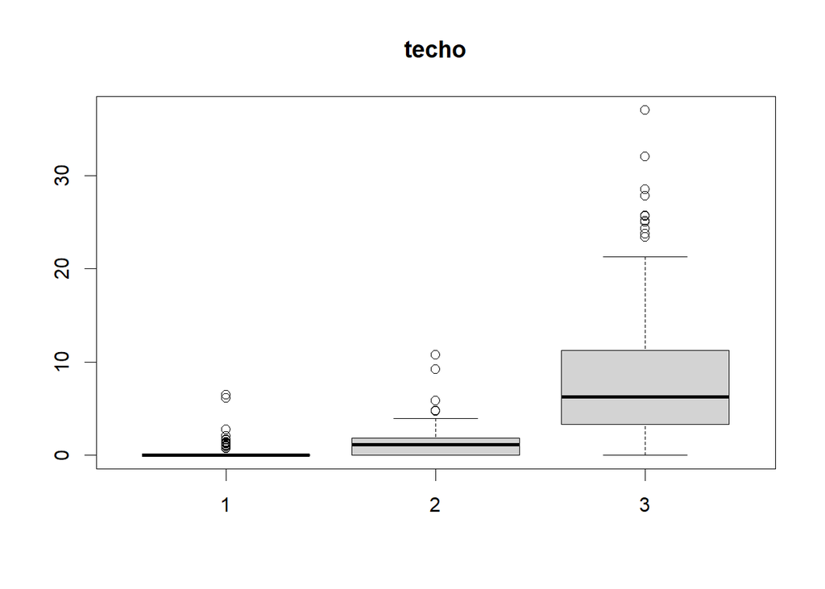

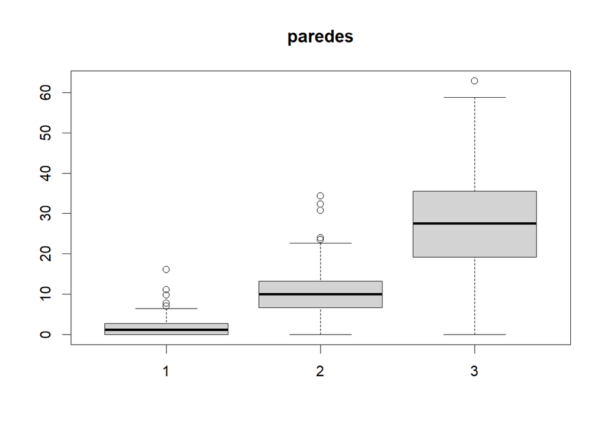

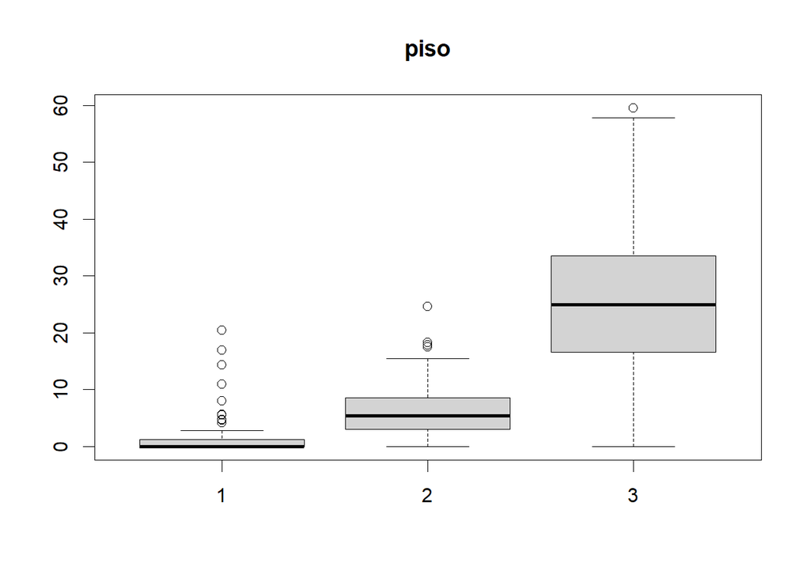

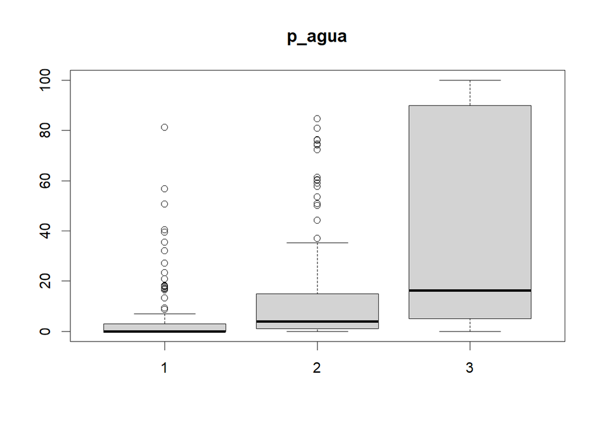

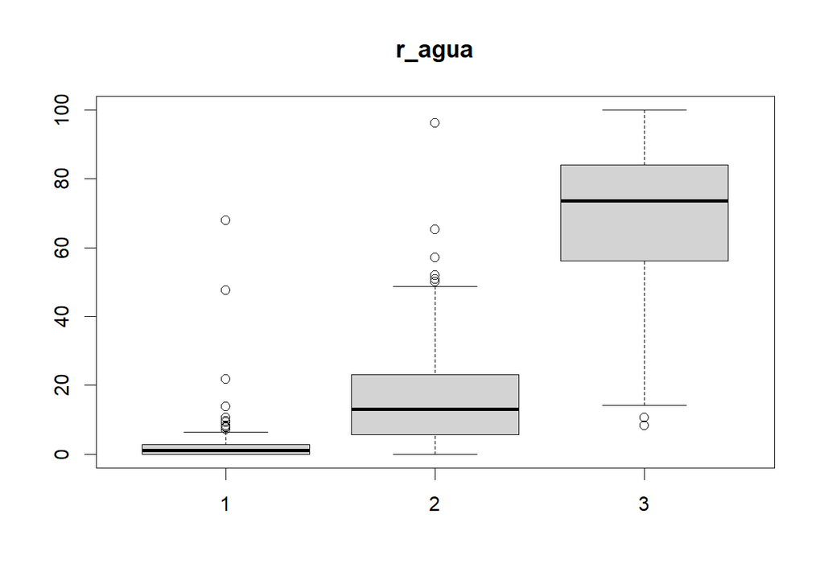

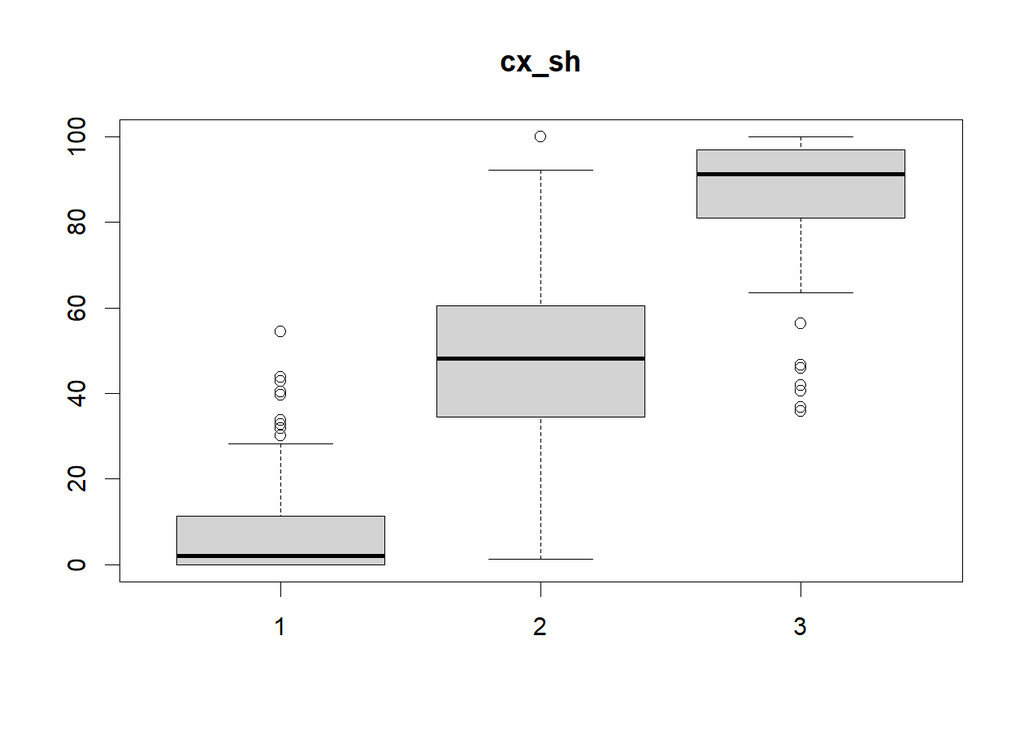

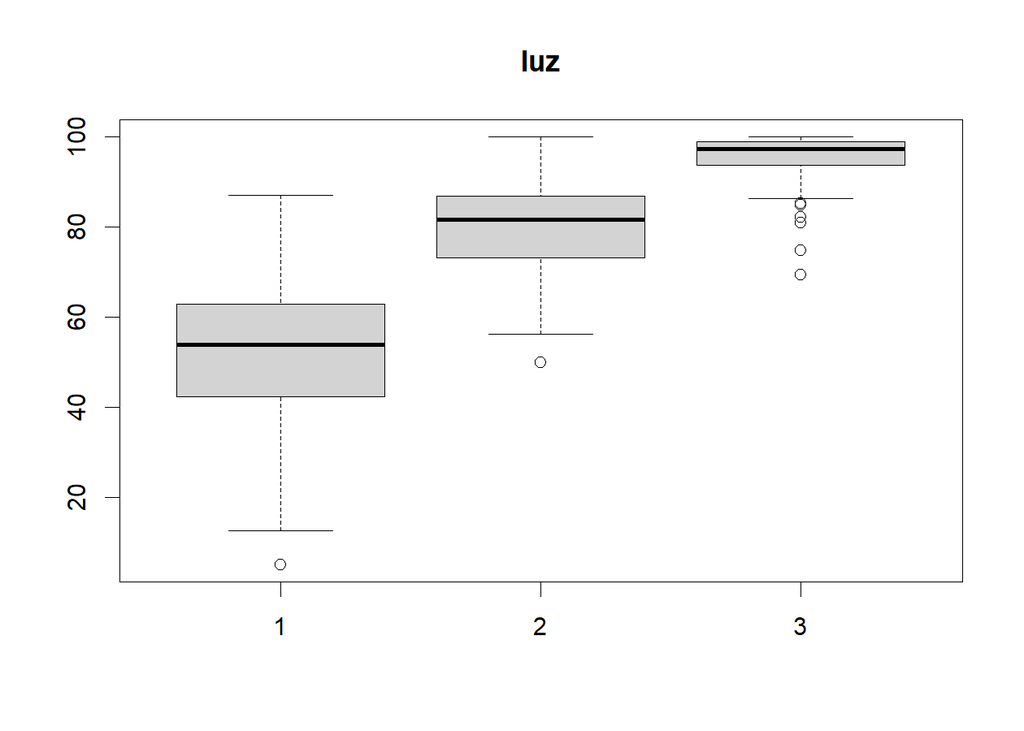

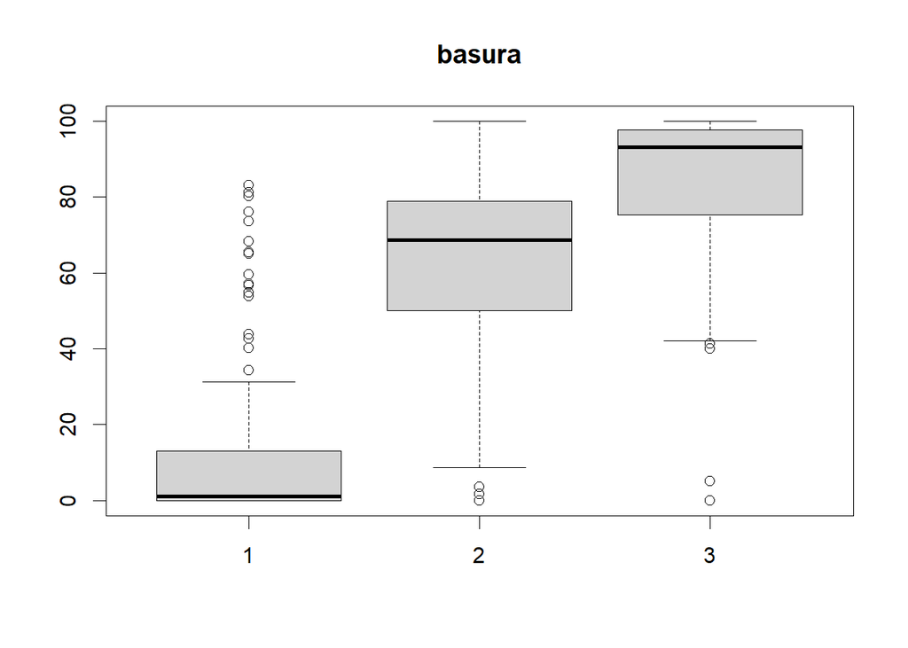

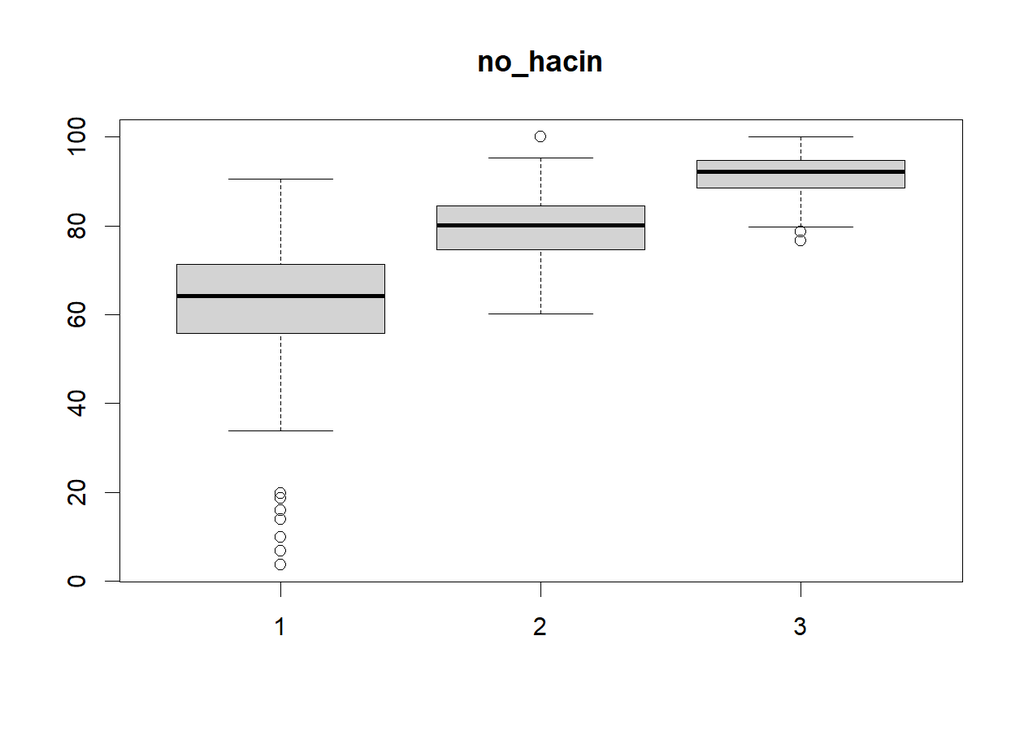

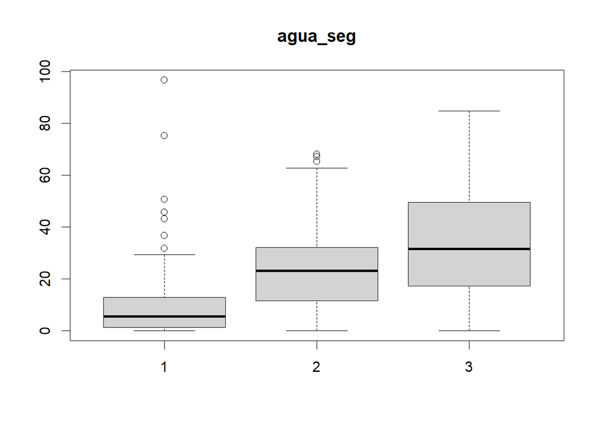

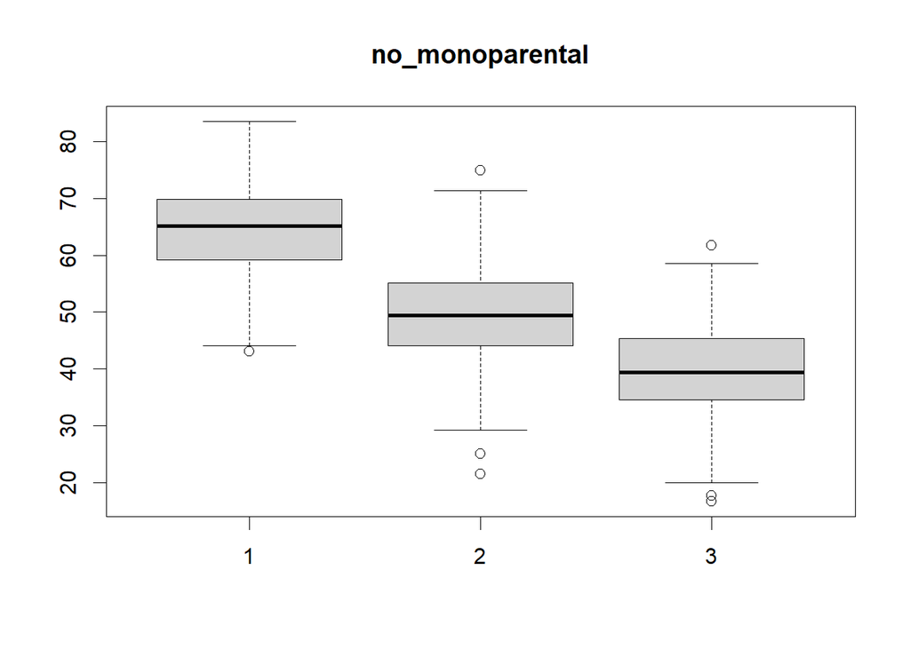

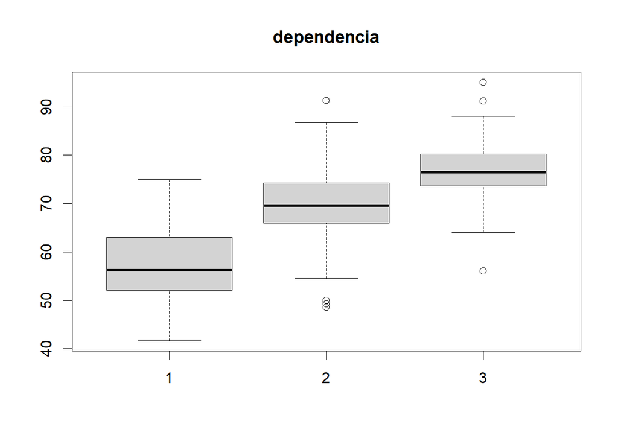

[21 more figures not shown]

Menor diseño de efecto generalizado